# Self-Driving Car Engineer Nanodegree

## Project: Build a Traffic Sign Recognition Classifier

In this notebook, a template is provided for you to implement your functionality in stages which is required to successfully complete this project. If additional code is required that cannot be included in the notebook, be sure that the Python code is successfully imported and included in your submission, if necessary. Sections that begin with **'Implementation'** in the header indicate where you should begin your implementation for your project. Note that some sections of implementation are optional, and will be marked with **'Optional'** in the header.

In addition to implementing code, there will be questions that you must answer which relate to the project and your implementation. Each section where you will answer a question is preceded by a **'Question'** header. Carefully read each question and provide thorough answers in the following text boxes that begin with **'Answer:'**. Your project submission will be evaluated based on your answers to each of the questions and the implementation you provide.

> **Note:** Code and Markdown cells can be executed using the **Shift + Enter** keyboard shortcut. In addition, Markdown cells can be edited by typically double-clicking the cell to enter edit mode.

## Step 0: Load The Data

```python
# Load pickled data
import pickle

# load the training and testing data
training_file = 'data/train.p'
testing_file = 'data/test.p'

with open(training_file, mode='rb') as f:
    train = pickle.load(f)
with open(testing_file, mode='rb') as f:
    test = pickle.load(f)

X_train, y_train = train['features'], train['labels']
X_test, y_test = test['features'], test['labels']
```

## Step 1: Dataset Summary & Exploration

The pickled data is a dictionary with 4 key/value pairs:

- `'features'` is a 4D array containing raw pixel data of the traffic sign images, (num examples, width, height, channels).
- `'labels'` is a 2D array containing the label/class id of the traffic sign. The file `signnames.csv` contains id -> name mappings for each id.
- `'sizes'` is a list containing tuples, (width, height) representing the the original width and height the image.
- `'coords'` is a list containing tuples, (x1, y1, x2, y2) representing coordinates of a bounding box around the sign in the image. **THESE COORDINATES ASSUME THE ORIGINAL IMAGE. THE PICKLED DATA CONTAINS RESIZED VERSIONS (32 by 32) OF THESE IMAGES**

Complete the basic data summary below.

```python
### Replace each question mark with the appropriate value.
import numpy as np

# Number of training examples
n_train = X_train.shape[0]

# Number of testing examples.
n_test = X_test.shape[0]

# What's the shape of an traffic sign image?
image_shape = X_train.shape[1:4]

# How many unique classes/labels there are in the dataset.
n_classes = len(np.unique(np.concatenate((y_train, y_test))))

print("Number of training examples =", n_train)
print("Number of testing examples =", n_test)
print("Image data shape =", image_shape)
print("Number of classes =", n_classes)
```

```
Number of training examples = 39209
Number of testing examples = 12630
Image data shape = (32, 32, 3)
Number of classes = 43
```

Visualize the German Traffic Signs Dataset using the pickled file(s). This is open ended, suggestions include: plotting traffic sign images, plotting the count of each sign, etc.

The [Matplotlib](http://matplotlib.org/) [examples](http://matplotlib.org/examples/index.html) and [gallery](http://matplotlib.org/gallery.html) pages are a great resource for doing visualizations in Python.

**NOTE:** It's recommended you start with something simple first. If you wish to do more, come back to it after you've completed the rest of the sections.

```python
### Data exploration visualization goes here.
### Feel free to use as many code cells as needed.
import matplotlib.pyplot as plt
# Visualizations will be shown in the notebook.
%matplotlib inline
```

### Sample Traffic Sign Images

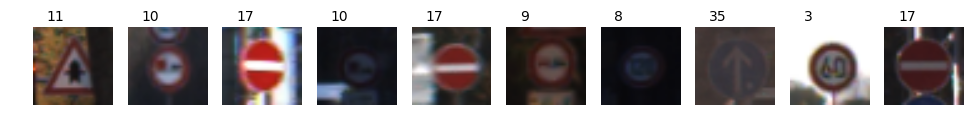

```python
# Plot sample traffic sign images
n_samples = 10
indexes = np.random.randint(0, n_train, n_samples)
fig, axs = plt.subplots(1, n_samples)
fig.set_size_inches(12, 4)
for i,index in enumerate(indexes):
    axs[i].axis('off')
    axs[i].text(5,-3, y_train[index])
    axs[i].imshow(X_train[index])
```

### Class distribution of Train/Test

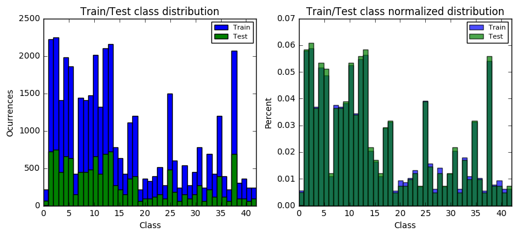

```python
def plot_class_distribution(y1, y2, y1_label='Train', y2_label='Test'):
    plt.figure(figsize=(10,4))
    # Train/test class distribution
    plt.subplot(121)
    plt.hist(y1, bins=n_classes, label=y1_label)
    plt.hist(y2, bins=n_classes, label=y2_label)
    plt.xlabel('Class')
    plt.ylabel('Ocurrences')
    plt.title('%s/%s class distribution' % (y1_label, y2_label))
    plt.xlim((0, n_classes-1))
    plt.legend(prop={'size':8})

    # Train/test class normalized distribution
    plt.subplot(122)
    plt.hist(y1, bins=n_classes, label=y1_label, normed=True, alpha=0.7)
    plt.hist(y2, bins=n_classes, label=y2_label, normed=True, alpha=0.7)
    plt.xlabel('Class')
    plt.ylabel('Percent')
    plt.title('%s/%s class normalized distribution' % (y1_label, y2_label))
    plt.xlim((0, n_classes-1))
    plt.legend(prop={'size':8})
    plt.show()

plot_class_distribution(y_train, y_test)
```

## Step 2: Design and Test a Model Architecture

Design and implement a deep learning model that learns to recognize traffic signs. Train and test your model on the [German Traffic Sign Dataset](http://benchmark.ini.rub.de/?section=gtsrb&subsection=dataset).

There are various aspects to consider when thinking about this problem:

- Neural network architecture
- Play around preprocessing techniques (normalization, rgb to grayscale, etc)
- Number of examples per label (some have more than others).
- Generate fake data.

Here is an example of a [published baseline model on this problem](http://yann.lecun.com/exdb/publis/pdf/sermanet-ijcnn-11.pdf). It's not required to be familiar with the approach used in the paper but, it's good practice to try to read papers like these.

**NOTE:** The LeNet-5 implementation shown in the classroom at the end of the CNN lesson is a solid starting point. You'll have to change the number of classes and possibly the preprocessing, but aside from that it's plug and play!

### Implementation

Use the code cell (or multiple code cells, if necessary) to implement the first step of your project. Once you have completed your implementation and are satisfied with the results, be sure to thoroughly answer the questions that follow.

```python
### Preprocess the data here.
### Feel free to use as many code cells as needed.
import cv2

def preprocess_images(images):
    # convert from RGB to YUV doesn't seems to help
    # yuv_images = np.array([cv2.cvtColor(images[i], cv2.COLOR_BGR2YUV) for i in range(images\.shape[0])])

    # convert from 0,255 to -1, 1
    return (images.astype(float)-128)/128.0

X_train_processed = preprocess_images(X_train)
X_test_processed = preprocess_images(X_test)
```

### Question 1

*Describe how you preprocessed the data. Why did you choose that technique?*

**Answer:**

My preprocess pipeline has just one step:

- Convert features from (0, 255) to (-1, 1): centralize the input data and keep it with zero mean and small variance to help the optimizer in finding a good solution.

I've tried to convert the images from RGB to YUV to offer an advantage to the model in using a color space that has a separated luminance component. But sadly the results doesn't improve. It seems that the model is strong enough to learn the same characteristics in a RGB color space.

```python
### Generate data additional data (OPTIONAL!)
### and split the data into training/validation/testing sets here.
### Feel free to use as many code cells as needed.

from sklearn.model_selection import train_test_split

# split train data using 80% for training and 20% for validation
x_train_processed_split, x_validation, y_train_split, y_validation = train_test_split(X_train_processed, y_train, test_size=0.2)
train_labels = y_train_split
validation_labels = y_validation
print("Train shape: ", x_train_processed_split.shape, train_labels.shape)
print("Validation size: ", x_validation.shape, validation_labels.shape)

# keep all test data for final evaluation
x_test = X_test_processed
test_labels = y_test
print("Test shape: ", x_test.shape, test_labels.shape)
```

```
Train shape:  (31367, 32, 32, 3) (31367,)
Validation size:  (7842, 32, 32, 3) (7842,)
Test shape:  (12630, 32, 32, 3) (12630,)
```

### Question 2

*Describe how you set up the training, validation and testing data for your model. **Optional**: If you generated additional data, how did you generate the data? Why did you generate the data? What are the differences in the new dataset (with generated data) from the original dataset?*

**Answer:**

I randomly splitted the training data and used 20% for validation. The supplied test set was fully used as the final test for the selected model.

Some classes are really under represented but, since the selected model is performing well, I chose to not generate fake data for this problem.

```python
### Define your architecture here.
### Feel free to use as many code cells as needed.
import tensorflow as tf

def conv2d(x, W, b, strides=1, padding='VALID'):
    # Conv2D wrapper, with bias and relu activation
    x = tf.nn.conv2d(x, W, strides=[1, strides, strides, 1], padding=padding)
    x = tf.nn.bias_add(x, b)
    return tf.nn.relu(x)

def maxpool2d(x, k=2):
    return tf.nn.max_pool(x, ksize=[1, k, k, 1], strides=[1, k, k, 1], padding='VALID')

tf.reset_default_graph()
x = tf.placeholder(tf.float32, (None, 32, 32, 3)) # features consists of 32x32x3 images
y = tf.placeholder(tf.int32, (None)) # Classify over 43 classes
one_hot_y = tf.one_hot(y, n_classes)
keep_prob = tf.placeholder(tf.float32)

mu = 0
sigma = 0.1

layer_width = {
    'conv_1': 16,
    'conv_2': 64,
    'fc_3': 512,
    'out': n_classes
}
weights = {
    'conv_1': tf.Variable(tf.truncated_normal([5, 5, 3, layer_width['conv_1']], mean = mu, stddev = sigma)),
    'conv_2': tf.Variable(tf.truncated_normal([5, 5, layer_width['conv_1'], layer_width['conv_2']], mean = mu, stddev = sigma)),
    'fc_3': tf.Variable(tf.truncated_normal([5*5*layer_width['conv_2'], layer_width['fc_3']], mean = mu, stddev = sigma)),
    'out': tf.Variable(tf.truncated_normal([layer_width['fc_3'], layer_width['out']], mean = mu, stddev = sigma))
}
biases = {
    'conv_1': tf.Variable(tf.zeros(layer_width['conv_1'])),
    'conv_2': tf.Variable(tf.zeros(layer_width['conv_2'])),
    'fc_3': tf.Variable(tf.zeros(layer_width['fc_3'])),
    'out': tf.Variable(tf.zeros(layer_width['out']))
}
conv1 = conv2d(x, weights['conv_1'], biases['conv_1'])
print("Shape of conv1: ", conv1.get_shape().as_list())
conv1 = maxpool2d(conv1)
print("Shape of conv1 after pooling: ", conv1.get_shape().as_list())
conv1 = tf.nn.dropout(conv1, keep_prob)

conv2 = conv2d(conv1, weights['conv_2'], biases['conv_2'])
print("Shape of conv2: ", conv2.get_shape().as_list())
conv2 = maxpool2d(conv2)
print("Shape of conv2 after pooling: ", conv2.get_shape().as_list())
conv2 = tf.nn.dropout(conv2, keep_prob)


fc3 = tf.contrib.layers.flatten(conv2)
print("Shape of fc3: ", fc3.get_shape().as_list())
fc3 = tf.add(tf.matmul(fc3, weights['fc_3']), biases['fc_3'])
fc3 = tf.nn.relu(fc3)
fc3 = tf.nn.dropout(fc3, keep_prob)

# Return the result of the last fully connected layer.
out = tf.add(tf.matmul(fc3, weights['out']), biases['out'])
print("Output shape: ", out.get_shape().as_list())

probabilities = tf.nn.softmax(out)
# add an small factor to prevent log(0)
loss_op = tf.reduce_mean(-tf.reduce_sum(one_hot_y * tf.log(probabilities + 1e-10), reduction_indices=1))
beta = 0.001
loss_l2 = tf.add(loss_op, tf.add_n([tf.nn.l2_loss(v) for _,v in weights.items()])*beta)

opt = tf.train.AdamOptimizer(learning_rate=0.001)
train_op = opt.minimize(loss_l2)
prediction = tf.argmax(out, 1)
correct_prediction = tf.equal(prediction, tf.argmax(one_hot_y, 1))
accuracy_op = tf.reduce_mean(tf.cast(correct_prediction, tf.float32))
```

```
Shape of conv1:  [None, 28, 28, 16]
Shape of conv1 after pooling:  [None, 14, 14, 16]
Shape of conv2:  [None, 10, 10, 64]
Shape of conv2 after pooling:  [None, 5, 5, 64]
Shape of fc3:  [None, 1600]
Output shape:  [None, 43]
```

### Question 3

*What does your final architecture look like? (Type of model, layers, sizes, connectivity, etc.) For reference on how to build a deep neural network using TensorFlow, see Deep Neural Network in TensorFlow from the classroom.*

**Answer:**

My deep learning model consist of four layers. The first is a convolution layer with a 5x5 kernel, the image data as inputs (32x32x3) and an output of 16 channels. This layer uses relu as the activation function. This layer also uses pooling (with k=2), so the output was reduced to 14x14x16.

The second layer is the same as the first layer but has an output with 64 channels. So the final output (after pooling) for this layer is 5x5x64.

The third is a fully connected layer, that receives the flattened second convolution layer as input and has an output of 512. This layer uses relu as the activation function.

The forth and final layer is also a fully connected layer that receives the above layer as input and has an output of 43 values, each one representing a probability for a class in respect of the input image.

Dropout with probability of 0.5 was used after each layer (except the output layer) to reduce overfitting. The model uses a loss function with regularization to be even more strong against overfitting.

```python
### model evaluation
from tqdm import tqdm_notebook
import math

BATCH_SIZE = 300

def next_batch(x, y, step, batch_size):
    start = step*batch_size
    return x[start:start+batch_size, ...], y[start:start+batch_size, ...]

def eval_data(features, labels):
    """
    Returns the loss and accuracy given features and labels as inputs.
    """
    num_examples = features.shape[0]
    steps_per_epoch = math.ceil(num_examples / BATCH_SIZE)
    total_acc, total_loss = 0, 0
    sess = tf.get_default_session()
    y_pred = np.array([])
    probs = []
    for step in range(steps_per_epoch):
        batch_x, batch_y = next_batch(features, labels, step, BATCH_SIZE)
        loss, acc, batch_pred, batch_prob = sess.run([loss_op, accuracy_op, prediction, probabilities], feed_dict={x: batch_x, y: batch_y, keep_prob: 1})
        total_acc += (acc * batch_x.shape[0])
        total_loss += (loss * batch_x.shape[0])
        y_pred = np.append(y_pred, batch_pred)
        probs.append(batch_prob)
    return total_loss/num_examples, total_acc/num_examples, y_pred, np.array(probs)[0]
```

```python
### Train your model here.
### Feel free to use as many code cells as needed.

EPOCHS = 50
saver = tf.train.Saver()
train_results, validation_results = [], []

with tf.Session() as sess:
    try:
        sess.run(tf.global_variables_initializer())
        num_examples = x_train_processed_split.shape[0]
        steps_per_epoch = math.ceil(num_examples / BATCH_SIZE)

        # Train model
        for i in tqdm_notebook(range(EPOCHS)):
            for step in tqdm_notebook(range(steps_per_epoch), leave=False):
                batch_x, batch_y = next_batch(x_train_processed_split, train_labels, step, BATCH_SIZE)
                loss = sess.run(train_op, feed_dict={x: batch_x, y: batch_y, keep_prob: 0.5})

            train_loss, train_acc, _, _ = eval_data(x_train_processed_split, train_labels)
            train_results.append([train_loss, train_acc])
            val_loss, val_acc, _, _ = eval_data(x_validation, validation_labels)
            validation_results.append([val_loss, val_acc])
            print("[EPOCH %d] Train/Validation loss = %.3f / %.3f, accuracy = %.3f / %.3f" % (i+1, train_loss, val_loss, train_acc, val_acc))

    except KeyboardInterrupt:
        print("stopped")
    finally:
        saver.save(sess, './models/model.ckpt')
```

```
[EPOCH 1] Train/Validation loss = 2.875 / 2.880, accuracy = 0.408 / 0.397
[EPOCH 2] Train/Validation loss = 1.496 / 1.504, accuracy = 0.681 / 0.662
[EPOCH 3] Train/Validation loss = 0.886 / 0.896, accuracy = 0.832 / 0.827
[EPOCH 4] Train/Validation loss = 0.523 / 0.537, accuracy = 0.906 / 0.902
[EPOCH 5] Train/Validation loss = 0.378 / 0.395, accuracy = 0.938 / 0.931
[EPOCH 6] Train/Validation loss = 0.281 / 0.297, accuracy = 0.955 / 0.952
[EPOCH 7] Train/Validation loss = 0.206 / 0.228, accuracy = 0.967 / 0.961
[EPOCH 8] Train/Validation loss = 0.182 / 0.202, accuracy = 0.975 / 0.970
[EPOCH 9] Train/Validation loss = 0.146 / 0.166, accuracy = 0.980 / 0.975
[EPOCH 10] Train/Validation loss = 0.122 / 0.142, accuracy = 0.983 / 0.979
[EPOCH 11] Train/Validation loss = 0.104 / 0.123, accuracy = 0.984 / 0.982
[EPOCH 12] Train/Validation loss = 0.097 / 0.118, accuracy = 0.987 / 0.982
[EPOCH 13] Train/Validation loss = 0.087 / 0.106, accuracy = 0.989 / 0.985
[EPOCH 14] Train/Validation loss = 0.081 / 0.100, accuracy = 0.988 / 0.983
[EPOCH 15] Train/Validation loss = 0.074 / 0.093, accuracy = 0.992 / 0.987
[EPOCH 16] Train/Validation loss = 0.066 / 0.085, accuracy = 0.992 / 0.988
[EPOCH 17] Train/Validation loss = 0.059 / 0.079, accuracy = 0.992 / 0.987
[EPOCH 18] Train/Validation loss = 0.057 / 0.077, accuracy = 0.994 / 0.989
[EPOCH 19] Train/Validation loss = 0.050 / 0.069, accuracy = 0.995 / 0.990
[EPOCH 20] Train/Validation loss = 0.050 / 0.068, accuracy = 0.995 / 0.989
[EPOCH 21] Train/Validation loss = 0.049 / 0.069, accuracy = 0.994 / 0.989
[EPOCH 22] Train/Validation loss = 0.047 / 0.067, accuracy = 0.995 / 0.989
[EPOCH 23] Train/Validation loss = 0.043 / 0.061, accuracy = 0.996 / 0.990
[EPOCH 24] Train/Validation loss = 0.043 / 0.062, accuracy = 0.995 / 0.990
[EPOCH 25] Train/Validation loss = 0.041 / 0.061, accuracy = 0.995 / 0.990
[EPOCH 26] Train/Validation loss = 0.042 / 0.061, accuracy = 0.995 / 0.989
[EPOCH 27] Train/Validation loss = 0.037 / 0.055, accuracy = 0.996 / 0.991
[EPOCH 28] Train/Validation loss = 0.036 / 0.055, accuracy = 0.996 / 0.991
[EPOCH 29] Train/Validation loss = 0.035 / 0.054, accuracy = 0.997 / 0.992
[EPOCH 30] Train/Validation loss = 0.031 / 0.049, accuracy = 0.997 / 0.991
[EPOCH 31] Train/Validation loss = 0.032 / 0.049, accuracy = 0.997 / 0.992
[EPOCH 32] Train/Validation loss = 0.035 / 0.053, accuracy = 0.996 / 0.991
[EPOCH 33] Train/Validation loss = 0.032 / 0.051, accuracy = 0.997 / 0.992
[EPOCH 34] Train/Validation loss = 0.026 / 0.045, accuracy = 0.997 / 0.992
[EPOCH 35] Train/Validation loss = 0.026 / 0.044, accuracy = 0.998 / 0.993
[EPOCH 36] Train/Validation loss = 0.028 / 0.045, accuracy = 0.997 / 0.992
[EPOCH 37] Train/Validation loss = 0.026 / 0.043, accuracy = 0.997 / 0.992
[EPOCH 38] Train/Validation loss = 0.031 / 0.048, accuracy = 0.997 / 0.992
[EPOCH 39] Train/Validation loss = 0.027 / 0.045, accuracy = 0.997 / 0.992
[EPOCH 40] Train/Validation loss = 0.026 / 0.043, accuracy = 0.997 / 0.992
[EPOCH 41] Train/Validation loss = 0.025 / 0.043, accuracy = 0.997 / 0.992
[EPOCH 42] Train/Validation loss = 0.025 / 0.042, accuracy = 0.997 / 0.992
[EPOCH 43] Train/Validation loss = 0.024 / 0.041, accuracy = 0.997 / 0.992
[EPOCH 44] Train/Validation loss = 0.026 / 0.043, accuracy = 0.997 / 0.991
[EPOCH 45] Train/Validation loss = 0.029 / 0.045, accuracy = 0.996 / 0.992
[EPOCH 46] Train/Validation loss = 0.027 / 0.044, accuracy = 0.997 / 0.992
[EPOCH 47] Train/Validation loss = 0.024 / 0.042, accuracy = 0.997 / 0.992
[EPOCH 48] Train/Validation loss = 0.022 / 0.041, accuracy = 0.998 / 0.993
[EPOCH 49] Train/Validation loss = 0.026 / 0.042, accuracy = 0.997 / 0.992
[EPOCH 50] Train/Validation loss = 0.022 / 0.040, accuracy = 0.997 / 0.993
```

### Train/Validation Results

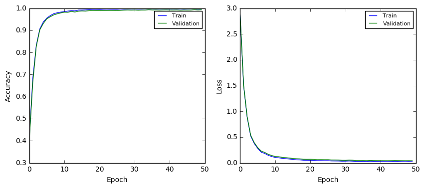

```python
# plot train/validation accuracy along epochs
plt.figure(figsize=(10,4))
plt.subplot(121)
plt.plot(np.array(train_results)[:,1], label="Train")
plt.plot(np.array(validation_results)[:,1], label="Validation")
plt.xlabel('Epoch')
plt.ylabel('Accuracy')
plt.legend(prop={'size':8}, loc='best')

plt.subplot(122)
plt.plot(np.array(train_results)[:,0], label="Train")
plt.plot(np.array(validation_results)[:,0], label="Validation")
plt.xlabel('Epoch')
plt.ylabel('Loss')
plt.legend(prop={'size':8}, loc='best')
plt.show()
```

### Test Results

```
Test loss = 0.139
Test accuracy = 0.963
```

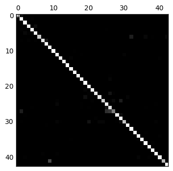

```
             precision    recall  f1-score   support

          0       1.00      0.92      0.96        60
          1       0.96      0.97      0.97       720
          2       0.95      0.99      0.97       750
          3       0.97      0.94      0.96       450
          4       0.99      0.97      0.98       660
          5       0.95      0.95      0.95       630
          6       1.00      0.81      0.89       150
          7       0.99      0.88      0.93       450
          8       0.91      0.99      0.95       450
          9       0.97      1.00      0.98       480
         10       1.00      0.98      0.99       660
         11       0.95      0.97      0.96       420
         12       0.99      0.97      0.98       690
```

[output cut: 32 more lines]

```python
from sklearn.metrics import confusion_matrix
from sklearn.metrics import classification_report

# Evaluate on the test data
saver = tf.train.Saver()
with tf.Session() as sess:
    saver.restore(sess, './models/model.ckpt')
    test_loss, test_acc, test_predictions, test_probabilities = eval_data(x_test, test_labels)
    print("Test loss = {:.3f}".format(test_loss))
    print("Test accuracy = {:.3f}".format(test_acc))
    cm = confusion_matrix(test_labels, test_predictions)
    cm = cm.astype('float') / cm.sum(axis=1)[:, np.newaxis] # normalize confusion matrix
    plt.matshow(cm, cmap='gray')
    plt.show()
    print(classification_report(test_labels, test_predictions))
```

### Question 4

*How did you train your model? (Type of optimizer, batch size, epochs, hyperparameters, etc.)*

**Answer:**

The Adam optimizer was used because it's a better fit to stochastic optimizations by controlling the learning rate along each round of training. The learning rate with the best results was 0.001. To prevent overfitting, the model uses a loss function with regularization (beta=0.001) and dropout (probability=0.5).

The batch size is 300 and the number of epochs is 50. However, after 20 epochs the results starts to improve very slowly but it's still relevant for the final results.

### Question 5

*What approach did you take in coming up with a solution to this problem? It may have been a process of trial and error, in which case, outline the steps you took to get to the final solution and why you chose those steps. Perhaps your solution involved an already well known implementation or architecture. In this case, discuss why you think this is suitable for the current problem.*

**Answer:**

I started my model based on the LeNet-5 implementation, modifying just the parameters that I need to have a working solution. The LeNet-5 model was successfully used in a similar problem (digit recognition) and so it has the properties that I need to solve the traffic signs recognition problem. After that, I started a process of trial and error, recording each achieved result and comparing with my previous choices.

The first things that I started to experiment was related to the learning rate, epochs and batch size. After that, I started to experiment with several modifications in the model architecture. I tested with from one to three convolution layers, and from one to three fully connected layers. Some complex configurations (more convolution layers) obtained a small improvement in the results but I gave priority to a simpler model, since these improvements seems to be irrelevant. So I kept the configuration that gave good results and that wasn't very complex, proceeding my experiments with the other customizable parameters.

Quickly, the need to fight against overfitting arose (the predictions over validation set weren't perform so well as in the training set) and I've added dropout in the model. It helped but I've complemented it with regularization and my validation results have become even better.

As last steps, I keep tuning my model playing around with kernel size (for convolution layers), output size for the hidden layers and dropout probability.

The model obtained an accuracy of 96.3% in the test set (see the detailed results above).

## Step 3: Test a Model on New Images

Take several pictures of traffic signs that you find on the web or around you (at least five), and run them through your classifier on your computer to produce example results. The classifier might not recognize some local signs but it could prove interesting nonetheless.

You may find `signnames.csv` useful as it contains mappings from the class id (integer) to the actual sign name.

### Implementation

Use the code cell (or multiple code cells, if necessary) to implement the first step of your project. Once you have completed your implementation and are satisfied with the results, be sure to thoroughly answer the questions that follow.

```
(9, 32, 32, 3)
```

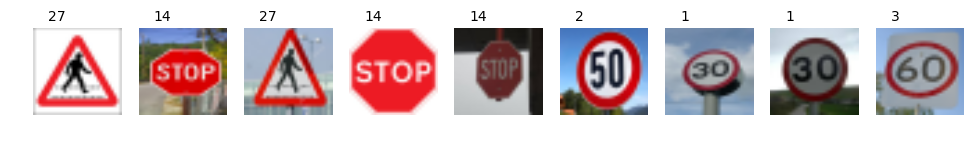

```python
### Load the images and plot them here.
### Feel free to use as many code cells as needed.
import matplotlib.image as mpimg
import os

new_images = os.listdir("images/")
fig, axs = plt.subplots(1, len(new_images))
fig.set_size_inches(12, 4)
new_labels = np.array([])
new_data = np.zeros((0, 32, 32, 3))
for i,new_image in enumerate(new_images):
    label = int(new_image.split('-')[0])
    new_labels = np.append(new_labels, label)
    image = mpimg.imread("images/"+new_image)
    resized_image = cv2.resize(image, (32, 32), interpolation=cv2.INTER_AREA)
    new_data = np.concatenate((new_data, resized_image[np.newaxis,:]))
    axs[i].axis('off')
    axs[i].text(5,-3, label)
    axs[i].imshow(resized_image)

print(new_data.shape)
new_data_processed = preprocess_images(new_data)
```

### Question 6

*Choose five candidate images of traffic signs and provide them in the report. Are there any particular qualities of the image(s) that might make classification difficult? It could be helpful to plot the images in the notebook.*

**Answer:**

I've chose images in different conditions (light, size and resolution) for five classes. I guess that the most difficulty for the model is in classification of the signs with different speed limits, because it are very similar between each other.

```python
### Run the predictions here.
### Feel free to use as many code cells as needed.

with tf.Session() as sess:
    saver.restore(sess, './models/model.ckpt')
    new_loss, new_acc, new_predictions, new_probabilities = eval_data(new_data_processed, new_labels)
```

### Question 7

*Is your model able to perform equally well on captured pictures when compared to testing on the dataset? The simplest way to do this check the accuracy of the predictions. For example, if the model predicted 1 out of 5 signs correctly, it's 20% accurate.*

**NOTE:** You could check the accuracy manually by using `signnames.csv` (same directory). This file has a mapping from the class id (0-42) to the corresponding sign name. So, you could take the class id the model outputs, lookup the name in `signnames.csv` and see if it matches the sign from the image.

**Answer:**

The model is 77.8% accurate in the new images:

- For the two wrong predictions, the certainties were of 57.1% (moderate) and 25.2% (low).
- For one correct prediction, the certainty was bellow the average: 41.6%.
- For the others correct predictions the certainties were from moderate to high.

```python
### Visualize the softmax probabilities here.
### Feel free to use as many code cells as needed.
print("Accuracy = {:.3f}".format(new_acc))
print("Labels:        ", new_labels)
print("Predictions:   ", new_predictions)
print("Probabilities: ", new_probabilities.max(axis=1))
```

```
Accuracy = 0.778
Labels:         [ 27.  14.  27.  14.  14.   2.   1.   1.   3.]
Predictions:    [ 27.  14.  27.  14.  14.   1.  10.   1.   3.]
Probabilities:  [ 0.65586227  0.99999285  0.58372945  0.99458957  0.91652143  0.57158208
  0.25205308  0.41623262  0.84026539]
```

### Question 8

*Use the model's softmax probabilities to visualize the **certainty** of its predictions, [`tf.nn.top_k`](https://www.tensorflow.org/versions/r0.12/api_docs/python/nn.html#top_k) could prove helpful here. Which predictions is the model certain of? Uncertain? If the model was incorrect in its initial prediction, does the correct prediction appear in the top k? (k should be 5 at most)*

`tf.nn.top_k` will return the values and indices (class ids) of the top k predictions. So if k=3, for each sign, it'll return the 3 largest probabilities (out of a possible 43) and the correspoding class ids.

Take this numpy array as an example:

```
# (5, 6) array
a = np.array([[ 0.24879643,  0.07032244,  0.12641572,  0.34763842,  0.07893497,
         0.12789202],
       [ 0.28086119,  0.27569815,  0.08594638,  0.0178669 ,  0.18063401,
         0.15899337],
       [ 0.26076848,  0.23664738,  0.08020603,  0.07001922,  0.1134371 ,
         0.23892179],
       [ 0.11943333,  0.29198961,  0.02605103,  0.26234032,  0.1351348 ,
         0.16505091],
       [ 0.09561176,  0.34396535,  0.0643941 ,  0.16240774,  0.24206137,
         0.09155967]])
```

Running it through `sess.run(tf.nn.top_k(tf.constant(a), k=3))` produces:

```
TopKV2(values=array([[ 0.34763842,  0.24879643,  0.12789202],
       [ 0.28086119,  0.27569815,  0.18063401],
       [ 0.26076848,  0.23892179,  0.23664738],
       [ 0.29198961,  0.26234032,  0.16505091],
       [ 0.34396535,  0.24206137,  0.16240774]]), indices=array([[3, 0, 5],
       [0, 1, 4],
       [0, 5, 1],
       [1, 3, 5],
       [1, 4, 3]], dtype=int32))
```

Looking just at the first row we get `[ 0.34763842, 0.24879643, 0.12789202]`, you can confirm these are the 3 largest probabilities in `a`. You'll also notice `[3, 0, 5]` are the corresponding indices.

**Answer:**

```python
with tf.Session() as sess:
    print(sess.run(tf.nn.top_k(new_probabilities, k=3)))
```

```
TopKV2(values=array([[  6.55862272e-01,   3.20107579e-01,   1.72144845e-02],
       [  9.99992847e-01,   5.22161918e-06,   5.66572510e-07],
       [  5.83729446e-01,   3.91710967e-01,   1.56095838e-02],
       [  9.94589567e-01,   5.00286045e-03,   1.21778547e-04],
       [  9.16521430e-01,   2.72031687e-02,   2.28600726e-02],
       [  5.71582079e-01,   4.28395778e-01,   2.19713347e-05],
       [  2.52053082e-01,   2.38869250e-01,   2.37171575e-01],
       [  4.16232616e-01,   2.45468244e-01,   1.15368053e-01],
       [  8.40265393e-01,   1.22079693e-01,   2.86928061e-02]], dtype=float32), indices=array([[27, 18, 26],
       [14, 17,  5],
       [27, 18, 26],
       [14, 29, 25],
       [14, 17, 32],
       [ 1,  2,  0],
       [10,  5,  2],
       [ 1, 16, 10],
       [ 3,  5,  2]], dtype=int32))
```

There are two wrong predictions. In the first, the correct class appears as the second ranked prediction. For the other image the correct class doesn't shows up in the top three.